# Coding the Monty Hall Problem

```python
import numpy as np
import pandas as pd
import random
import matplotlib.pyplot as plt
from sklearn.linear_model import LinearRegression
import scipy
from IPython.display import IFrame
```

On the drive to work this morning, I had 'shower thought'. "how tricky would it be to code up a demonstration of the Monty Hall problem?". It'd had been floating around my head since I re-watched a film called "21", which follows the exploits of the a group of gifted mathematics students, led by their professor, as they try to bleed Vegas Casino's dry, by counting cards. One scene used to display the main characters mathematical prowess features the Monty Hall problem. See below for details.

```python
IFrame(width="560", height="315",
       src="https://www.youtube.com/embed/iBdjqtR2iK4?start=71")
```

[video not shown]

In summary, imagine you're on a game-show and there are 3 closed doors. Behind one door is a car (or other desirable item) and behind the other two doors are goats (or other not desirable item. You're asked to choose a door, but before you open it, the game show host opens another door which contains a goat, and then asks do you want to switch doors. The Monty Hall problem asks whether it's in your interest to switch doors after the location of one goat is revealed.

Indeed, if you never switch your chance of success is 33.33%, however, initially counter-intuitively, if you change your position, your chance of success is 50%. Let's do some simulations.

P.S. There's a lot of history surrounding this problem, and trying to explain it in a notebook wouldn't do it justice, Vox has a good [video](https://www.youtube.com/watch?v=ggDQXlinbME) on it, if your interested.

For the trivial case where a player picks a door at random and never changes their choice after being shown a goat, we expect a success probability of 0.33.

We'll do 100,000 simulations per case.

```python
# we will treat 1 as the car and 0 as a goat
# these are the only 3 arrangements of the goats and cars
arr1 = [0, 0, 1]
arr2 = [1, 0, 0]
arr3 = [0, 1, 0]
```

```python
check = 0
results_player1 = []
while check <= 100000:

    # this is the arrangement of items behind doors for this iteration of the sim
    this_arr = np.array(random.choice([arr1, arr2, arr3]))

    # this is the choice the player has made
    this_choice = random.choice([0, 1, 2])

    # determine if the player wins or not
    if this_arr[this_choice] == 1:
        results_player1.append(True)
    else:
        results_player1.append(False)

    # increment the counter by 1
    check += 1
```

```python
# what is the percentage of wins for the player who randomly chooses and never changes?
player1_percen = np.sum(results_player1) / 100000*100
player1_percen
```

```
33.373000000000005
```

Looks good. What about the non-trivial case where the player always changes their choice after being shown a goat?

```python
check = 0
results_player2 = []
while check <= 100000:

    # this is the arrangement of items behind doors for this iteration of the sim
    this_arr = np.array(random.choice([arr1, arr2, arr3]))

    # this is the choice the player has made
    this_choice = random.choice([0, 1, 2])

    # this is the index of the winning door
    winning_ix = np.where(this_arr == 1)

    # these are the indices of the goats
    remaining_duds = list((set({0, 1, 2}) - {winning_ix[0][0]}))

    # this is the index of the revealed dud
    revealed_dud = np.random.choice(remaining_duds)

    # the final choice for this player becomes the door that wasn't picked
    # initially and wasn't opened by the host
    final_choice = list(set({0, 1, 2}) - {this_choice} - {revealed_dud})[0]

    # determine if the player wins or not
    if this_arr[final_choice] == 1:
        results_player2.append(True)
    else:
        results_player2.append(False)

    # increment the counter by 1
    check += 1
```

```python
# what is the percentage of wins for the player who always changes their mind?
player2_percen = np.sum(results_player2) / 100000*100
player2_percen
```

```
49.945
```

Woop! Final case, what happens if after the reveal of a goat, our player decides to change door only 50% of the time. A priori, what do I expect the result to be? Somewhere between this first two results? So...

```python
def midpoint(p1, p2):
    return p1 + (p2-p1)/2     # or *0.5


midpoint(player1_percen, player2_percen)
```

```
41.659000000000006
```

But we know those values should be 33.33 and 50...

```python
midpoint(33.33, 50)
```

```
41.665
```

So, my guess is 41.665

# Player 3

Some thoughts about player 3

This player is interesting and there's a couple ways to code them. We can have in the simplest case the player flipping a coin (i.e. choosing at random 0 or 1) and using that to push them down one of two paths. Or we could implement a parameter which is the frequency at which they change their mind (could also be stick to their choice, but I'm going with an affirmative action as changing doors.

This gives us a question to solve, how do we want to implement the variability of the choice. This feel like a dice-based problem. Flipping a coin is just like rolling a 'two-sided dice'. If we want the player to change only 25% of the time, we assign them a four sided dice, 16.6% would be a six-sided die, etc. So, we're looking for a way of implementing an arbitrary system for scaling the 'die'.

We could just say that if we're doing 100000 simulations and we want to see the result for 25% chance of changing door, then we can implement method 2 for the first 25000 simulations, and method 1 for the rest. But that doesn't feel like a good way to implement it.

First on the list of things to do then is create a method of selecting one of two variables at an uneven distribution. Numpy has us covered here, but lets just run some simulations to make sure it's doing what we want.

```python
change_mind_freq = 0.5
check = 0
counts = []
while check <= 10000:
    counts.append(np.random.choice(
        [0, 1], 1, p=[1-change_mind_freq, change_mind_freq])[0])
    check += 1

np.sum(counts) / len(counts)
```

```
0.49735026497350265
```

```python
change_mind_freq = 0.3
check = 0
counts = []
while check <= 10000:
    counts.append(np.random.choice(
        [0, 1], 1, p=[1-change_mind_freq, change_mind_freq])[0])
    check += 1

np.sum(counts) / len(counts)
```

```
0.2947705229477052
```

```python
change_mind_freq = 0.1
check = 0
counts = []
while check <= 10000:
    counts.append(np.random.choice(
        [0, 1], 1, p=[1-change_mind_freq, change_mind_freq])[0])
    check += 1

np.sum(counts) / len(counts)
```

```
0.1014898510148985
```

Perfect! Now lets implement this into the game.

```python
change_mind_freq = 0.5
check = 0
results_player3 = []
while check <= 100000:

    # if change_mind is one our player will change their mind
    # if it's 0 they wont
    change_mind = np.random.choice(
        [0, 1], 1, p=[1-change_mind_freq, change_mind_freq])[0]

    if change_mind == 0:

        this_arr = np.array(random.choice([arr1, arr2, arr3]))

        this_choice = random.choice([0, 1, 2])

        if this_arr[this_choice] == 1:
            results_player3.append(True)
        else:
            results_player3.append(False)

        check += 1

    if change_mind == 1:

        this_arr = np.array(random.choice([arr1, arr2, arr3]))

        this_choice = random.choice([0, 1, 2])

        winning_ix = np.where(this_arr == 1)

        remaining_duds = list((set({0, 1, 2}) - {winning_ix[0][0]}))

        revealed_dud = np.random.choice(remaining_duds)

        final_choice = list(set({0, 1, 2}) - {this_choice} - {revealed_dud})[0]

        if this_arr[final_choice] == 1:
            results_player3.append(True)
        else:
            results_player3.append(False)

        check += 1
```

```python
# what is the percentage of wins for the player who always changes their mind 50% of
# the time?
player3_percen = np.sum(results_player3) / 100000 * 100
player3_percen
```

```
41.699999999999996
```

Call it a lucky guess I suppose? What's interesting about this loop is that it makes the first two functions redundant, because we can set change_mind_freq to 0 in the first case where our player never changes their mind and 1 in the case where they always change their mind. Let's write it into a function then.

```python
def montyhall(nsim, change_mind_freq):
    """Run a simulation of the Monty Hall Problem with varying probabilities that
    player will change their mind.

    Parameters
    ----------
    nsim : int
        The number of simulations to run.
    change_mind_freq: int
        The probability that the player will change their mind and choose the
        alternate door.

    Returns
    ----------
    percen_win : The percentage of games won by the player (wins/nsim)

    Notes
    ----------
    If you want the player to always change their mind then set change_mind_freq to
    1, the converse is true, if you want the player to never change their mind, set
    change_mind_freq to 0."""

    # check the inputs
    assert isinstance(nsim, int), "nsim should be a positive integer > 0"
    assert nsim > 0, "nsim needs to be a postive integer > 0"
    assert change_mind_freq >= 0 and change_mind_freq <= 1, "change_mind_freq should be a value between >=0 and <=1"

    check = 0
    results = []

    arr1 = [0, 0, 1]
    arr2 = [1, 0, 0]
    arr3 = [0, 1, 0]

    while check <= nsim:

        change_mind = np.random.choice(
            [0, 1], 1, p=[1-change_mind_freq, change_mind_freq])[0]

        if change_mind == 0:

            this_arr = np.array(random.choice([arr1, arr2, arr3]))

            this_choice = random.choice([0, 1, 2])

            if this_arr[this_choice] == 1:
                results.append(True)
            else:
                results.append(False)

            check += 1

        if change_mind == 1:

            this_arr = np.array(random.choice([arr1, arr2, arr3]))

            this_choice = random.choice([0, 1, 2])

            winning_ix = np.where(this_arr == 1)

            remaining_duds = list((set({0, 1, 2}) - {winning_ix[0][0]}))

            revealed_dud = np.random.choice(remaining_duds)

            final_choice = list(
                set({0, 1, 2}) - {this_choice} - {revealed_dud})[0]

            if this_arr[final_choice] == 1:
                results.append(True)
            else:
                results.append(False)

            check += 1

    percen_win = np.sum(results) / nsim*100

    return percen_win
```

```python
montyhall(100000, 1)
```

```
50.07899999999999
```

```python
montyhall(100000, 0)
```

```
33.355000000000004
```

```python
montyhall(100000, 0.5)
```

```
41.802
```

Looking great. Now that we have it generalised it's fairly easy to plot the success over the changing probabilities.

```python
# define a range of probabilities for the varying change_mind_freq arguement
probs = np.linspace(0, 1, 50)
```

```python
# run 100,000 simulations for each probability value
success = []
for prob in probs:
    success.append(montyhall(100000, prob))
```

```python
# helper function
def abline(slope, intercept):
    """Plot a line from slope and intercept"""
    axes = plt.gca()
    x_vals = np.array(axes.get_xlim())
    y_vals = intercept + slope * x_vals
    plt.plot(x_vals, y_vals, '--', color='orange')
```

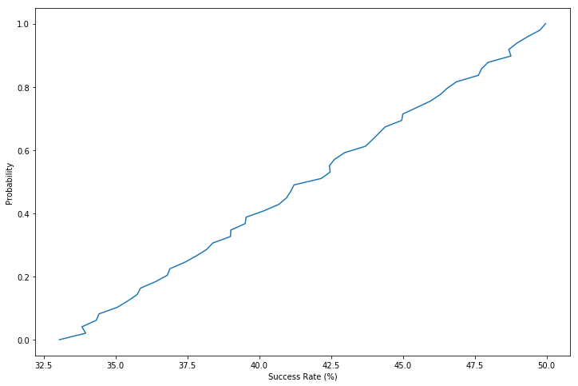

```python
# plot the results over changing change_mind_frequencies
plt.figure(figsize=(12, 8))
plt.plot(success, probs)
plt.ylabel('Probability')
plt.xlabel('Success Rate (%)')
plt.show()
```

...and finally, seeing as how we have a nice line, let's see what the function of that line is.

```python
slope, intercept, rvalue, pvalue, stderr = scipy.stats.linregress(
    success, probs)

'The model fitted with a slope of {}, an intercept of {}, with an R value of (p={})'.format(
    slope, intercept, rvalue, pvalue)
```

```
'The model fitted with a slope of 0.05950140578677803, an intercept of -1.9793783580666426, with an R value of (p=0.9994339194610821)'
```

Let's update that graph

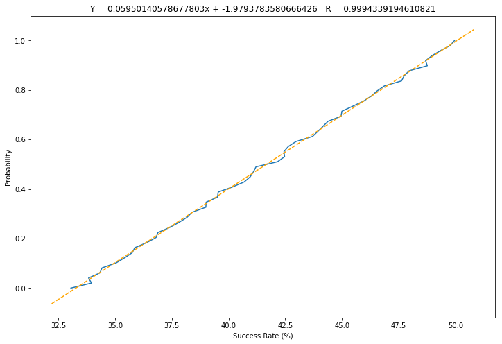

```python
plt.figure(figsize=(12, 8))
plt.plot(success, probs)
plt.ylabel('Probability')
plt.xlabel('Success Rate (%)')
abline(slope, intercept)
plt.title('Y = {}x + {}   R = {}'.format(slope, intercept, rvalue))
plt.show()
```

To estimate success rate of a given probability we can use x = (y - c) / m

```python
predicted = []
for prob in probs:
    predicted.append(((prob - intercept) / slope))
```

```python
master_results = pd.DataFrame(
    {'success': success, 'predicted': predicted, 'probability': probs},
    columns=['probability', 'predicted', 'success'])
master_results['difference'] = master_results['predicted'] - \
    master_results['success']
```

```python
master_results
```

|  | probability | predicted | success | difference |
| --- | --- | --- | --- | --- |
| 0 | 0.000000 | 33.266077 | 33.046 | 0.220077 |
| 1 | 0.020408 | 33.609063 | 33.957 | -0.347937 |
| 2 | 0.040816 | 33.952050 | 33.827 | 0.125050 |
| 3 | 0.061224 | 34.295036 | 34.324 | -0.028964 |
| 4 | 0.081633 | 34.638022 | 34.423 | 0.215022 |
| 5 | 0.102041 | 34.981008 | 35.048 | -0.066992 |
| 6 | 0.122449 | 35.323995 | 35.420 | -0.096005 |
| 7 | 0.142857 | 35.666981 | 35.750 | -0.083019 |
| 8 | 0.163265 | 36.009967 | 35.867 | 0.142967 |
| 9 | 0.183673 | 36.352953 | 36.391 | -0.038047 |
| 10 | 0.204082 | 36.695940 | 36.803 | -0.107060 |
| 11 | 0.224490 | 37.038926 | 36.887 | 0.151926 |
| 12 | 0.244898 | 37.381912 | 37.407 | -0.025088 |
| 13 | 0.265306 | 37.724898 | 37.813 | -0.088102 |
| 14 | 0.285714 | 38.067885 | 38.169 | -0.101115 |
| 15 | 0.306122 | 38.410871 | 38.387 | 0.023871 |
| 16 | 0.326531 | 38.753857 | 38.998 | -0.244143 |
| 17 | 0.346939 | 39.096843 | 39.010 | 0.086843 |
| 18 | 0.367347 | 39.439829 | 39.511 | -0.071171 |
| 19 | 0.387755 | 39.782816 | 39.542 | 0.240816 |
| 20 | 0.408163 | 40.125802 | 40.172 | -0.046198 |
| 21 | 0.428571 | 40.468788 | 40.687 | -0.218212 |
| 22 | 0.448980 | 40.811774 | 40.950 | -0.138226 |
| 23 | 0.469388 | 41.154761 | 41.096 | 0.058761 |
| 24 | 0.489796 | 41.497747 | 41.209 | 0.288747 |
| 25 | 0.510204 | 41.840733 | 42.158 | -0.317267 |
| 26 | 0.530612 | 42.183719 | 42.469 | -0.285281 |
| 27 | 0.551020 | 42.526706 | 42.441 | 0.085706 |
| 28 | 0.571429 | 42.869692 | 42.630 | 0.239692 |
| 29 | 0.591837 | 43.212678 | 42.971 | 0.241678 |
| 30 | 0.612245 | 43.555664 | 43.698 | -0.142336 |
| 31 | 0.632653 | 43.898651 | 43.934 | -0.035349 |
| 32 | 0.653061 | 44.241637 | 44.159 | 0.082637 |
| 33 | 0.673469 | 44.584623 | 44.382 | 0.202623 |
| 34 | 0.693878 | 44.927609 | 44.959 | -0.031391 |
| 35 | 0.714286 | 45.270595 | 44.997 | 0.273595 |
| 36 | 0.734694 | 45.613582 | 45.482 | 0.131582 |
| 37 | 0.755102 | 45.956568 | 45.955 | 0.001568 |
| 38 | 0.775510 | 46.299554 | 46.296 | 0.003554 |
| 39 | 0.795918 | 46.642540 | 46.545 | 0.097540 |
| 40 | 0.816327 | 46.985527 | 46.868 | 0.117527 |
| 41 | 0.836735 | 47.328513 | 47.628 | -0.299487 |
| 42 | 0.857143 | 47.671499 | 47.737 | -0.065501 |
| 43 | 0.877551 | 48.014485 | 47.961 | 0.053485 |
| 44 | 0.897959 | 48.357472 | 48.762 | -0.404528 |
| 45 | 0.918367 | 48.700458 | 48.686 | 0.014458 |
| 46 | 0.938776 | 49.043444 | 48.972 | 0.071444 |
| 47 | 0.959184 | 49.386430 | 49.346 | 0.040430 |
| 48 | 0.979592 | 49.729417 | 49.769 | -0.039583 |
| 49 | 1.000000 | 50.072403 | 49.963 | 0.109403 |

An interesting coding problem to be sure, not as tricky as I initially imagined it would be. Hopefully this is interesting to someone. As always, criticism and discussion of the methods I've used to answer this problem are entirely welcome. Also, if you know of any other cool coding problems, feel free to send them my way.

Happy Coding,

Sean